# Democratic Breakdown and Terrorism

7/23/2019

## What explains the variation in terrorism across countries and years?

The most common finding in the terrorism literature is that terrorism is most common in democracies (Chenoweth 2013).

Several proposed reasons:

1. Competitive spaces (Chenoweth 2010)
2. Easy to coerce change through public opinion (Pape 2003)
3. Intransigence (Young and Dugan 2011)
4. Opportunity
   - civil liberties make organization easier (Eubank and Weinberg 1994)
   - press freedom makes terrorism more visible (Hoffman 2006)

## Full, stable democracies are not the problem

Characteristics of a democracy:

- frequent, free, and competitive elections
- constrained executives
- protected civil and political freedoms

New democracies experience more terrorism (Piazza 2013).

The relationship between democratic-ness and terrorism is curvilinear (Abadie 2006).

## What is it about struggling democracies?

- Less capable state apparatus
- Less developed grievance mechanisms
- Less economic development

None of these explain why citizens resort to violence instead of legal political action.

## Political disillusionment and democratic breakdowns

Democratic breakdown:

- A country that was coded a democracy in year \(t-1\) is no longer considered a democracy in year \(t\) (Boix, Miller, and Rosato 2013).

Most of the world’s weak democracies have had previous democratic breakdowns.

- political disillusionment
- lack of faith in legal political processes
- experience with freedoms being revoked

Once faith in legal processes is gone, citizens must resort to any means necessary to accomplish political goals.

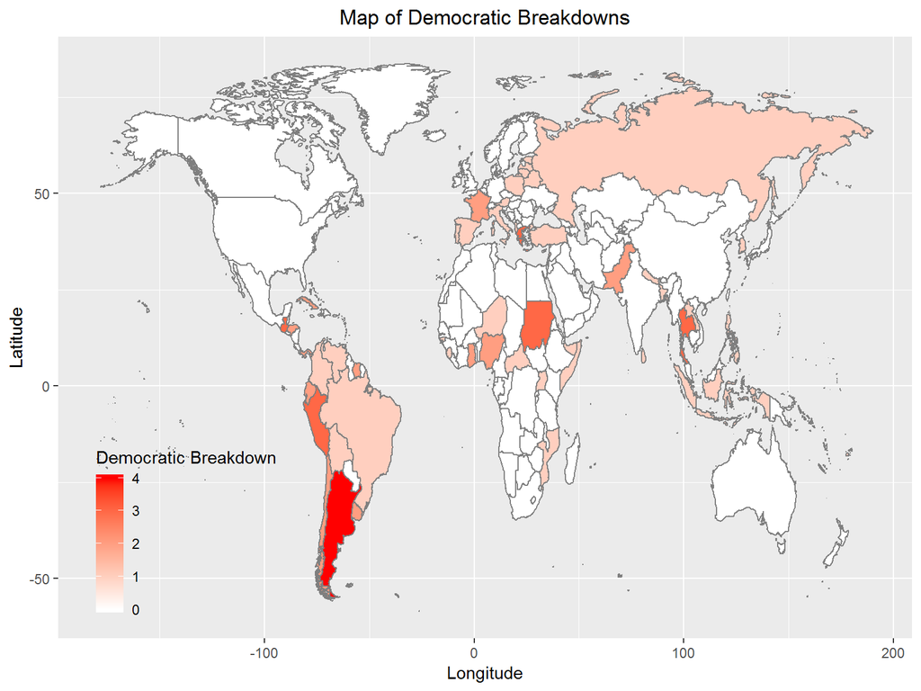

## Terrorism Timelines

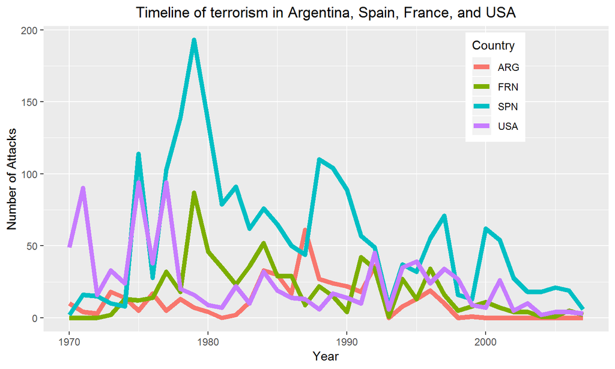

## Distribution of Terrorist Attacks

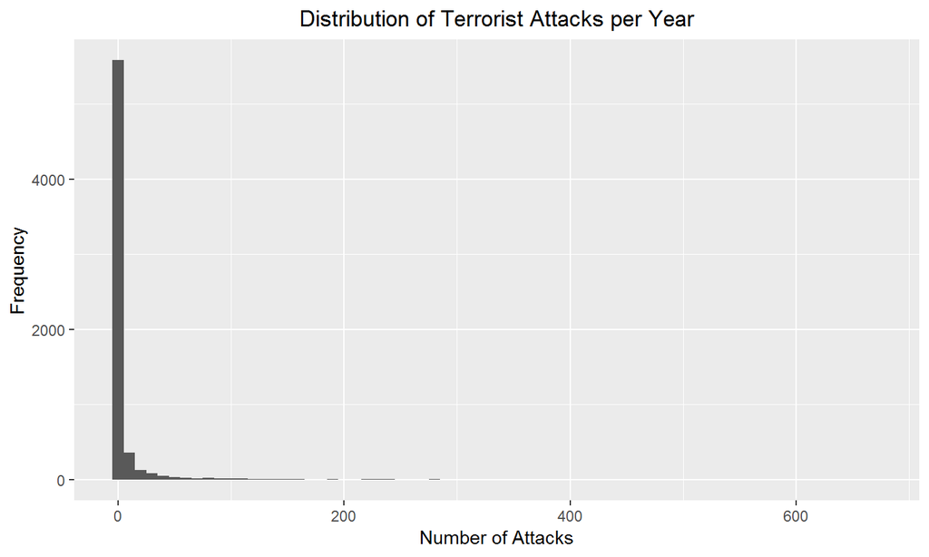

## Percent of Country-Years with Attack

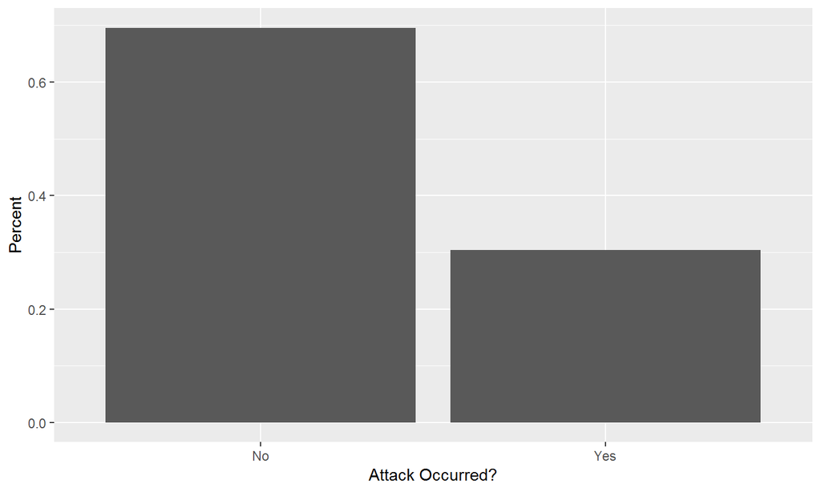

Must account for the abundance of rows with zero attacks.

## Analytic Outline

1. Variables of Interest
2. Dealing with missing data
3. Estimating zero inflated negative binomial models
4. Extreme bounds analysis

## Missing Data: Population

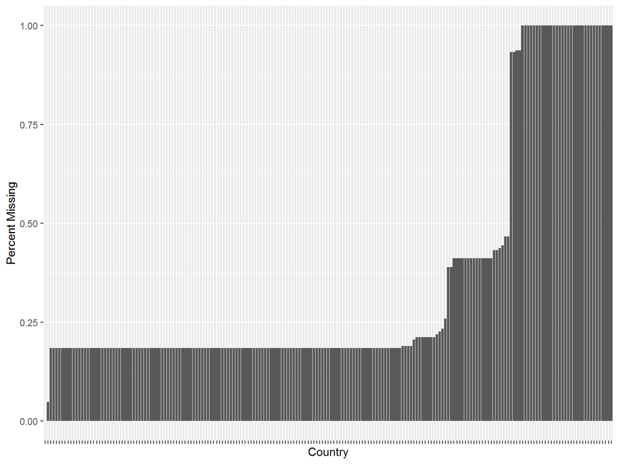

If 100% observations are missing, drop the country. If <100% are missing, replace with mean.

Population is slow-moving over time, so while not perfect this is better than dropping several hundred observations.

## Missing Data: Everything Else

AMELIA II package in R using (Honaker, King, and Blackwell 2011)

Assume:

- The full data \(D\) is distributed multivariate normal \(D\sim N(\mu,\Sigma)\) where \(\mu\) is a vector of means and \(\Sigma\) is a covariance matrix.
- Data is missing at random (MAR)
- Expectation Maximization with Bootstrapping (EMB) algorithm
  - Bootstraps from a the posterior distribution of the likelihood function found from assuming the data is MAR and a flat prior assumption of the multivariate normal distribution.

## Zero-inflated negative binomial (ZINB) regression

Two-stages:

1. Logit to see the probability there are zero attacks
2. If there is an attack, negative binomial to estimate how many

A regular negative binomial produces about the same results, but the ZINB more properly accounts for the over-representation of zeros.

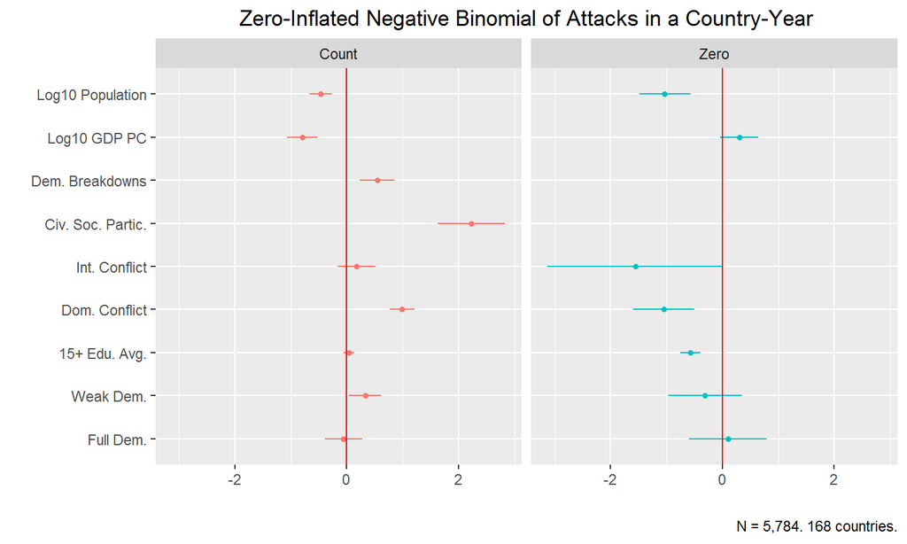

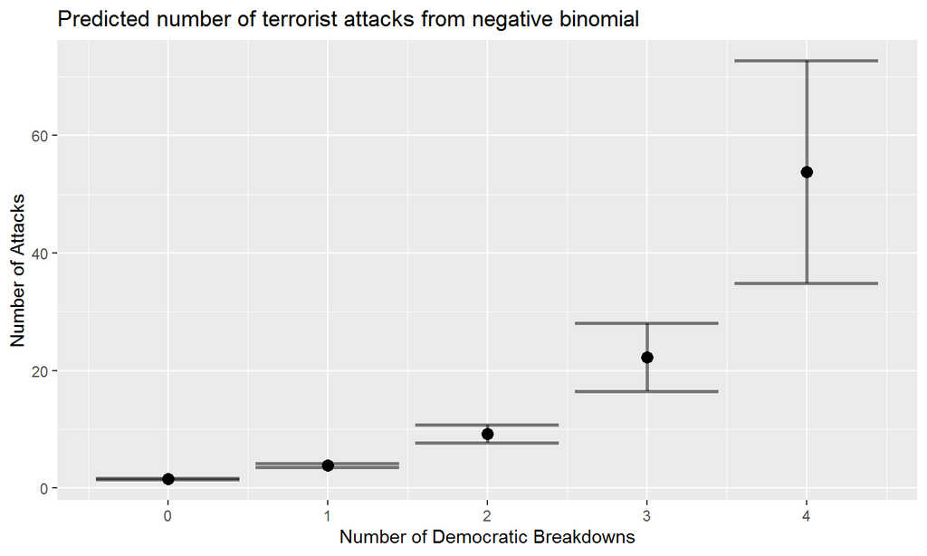

## Extreme Bounds Analysis (EBA)

\(y = \alpha_j + \beta_jv + \gamma_jF + \delta_jD + \epsilon\)

\(v\):(optional) variable of focus to test its robustness  
\(F\): vector of ‘free’ variables integral to correct estimation and always included \(D\): vector of ‘doubtful’ variables, a permutation of which is included in each regression

1. Iteratively estimate an OLS regression with a different permutations of the regressors predicting the outcome.
   - Restrict models based on a variance inflation factor (vif < 7) to avoid high multicollinearity.
   - Use heteroskedasticity robust standard errors
   - Weigh regressions according to the resultant \(\bar{R}^2\)
2. Interpret the distribution of coefficients from each model as a robustness measures of variable importance.

## EBA Details

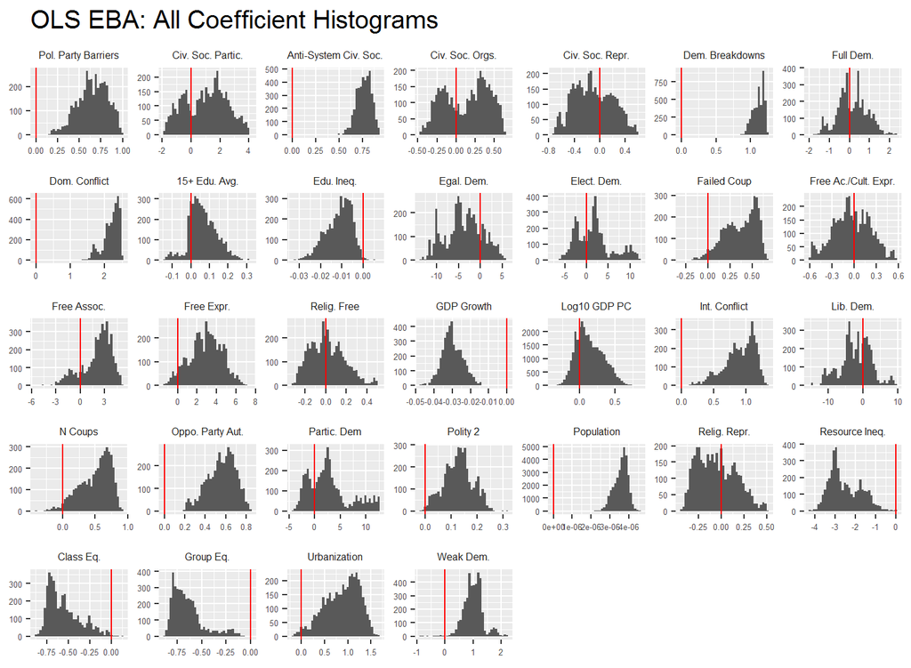

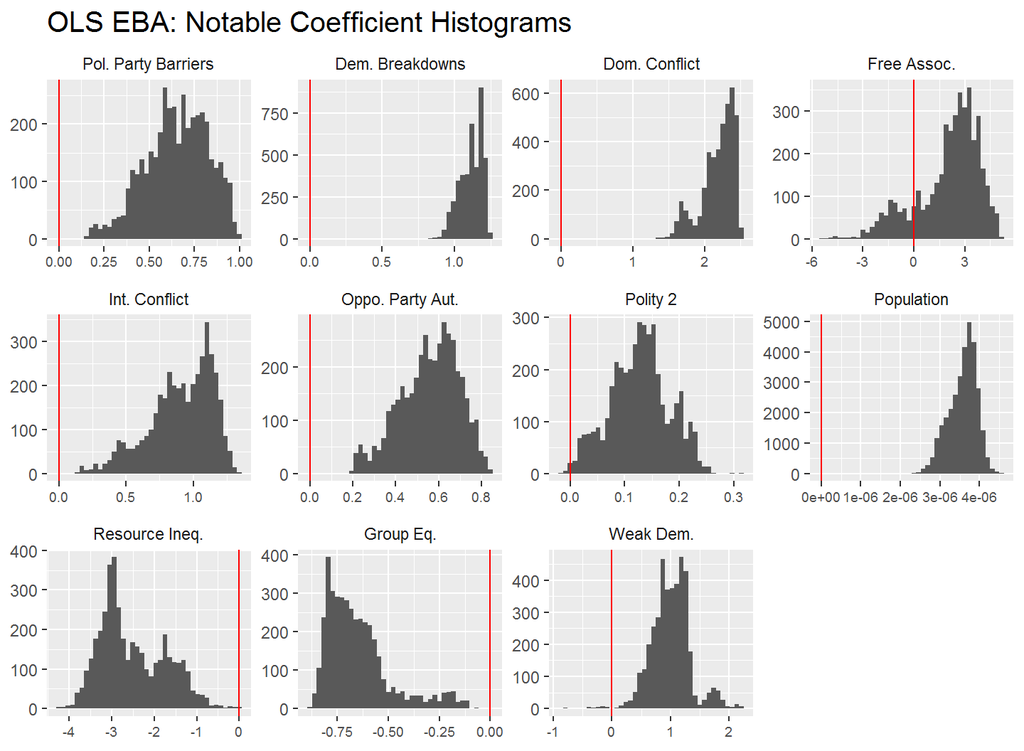

## References

Abadie, Alberto. 2006. “Poverty, Political Freedom, and the Roots of Terrorism.” *American Economic Review* 96 (2): 50–56. https://doi.org/10.1257/000282806777211847.

Boix, Carles, Michael Miller, and Sebastian Rosato. 2013. “A Complete Data Set of Political Regimes, 1800–2007.” *Comparative Political Studies* 46 (12): 1523–54. https://doi.org/10.1177/0010414012463905.

Chenoweth, Erica. 2010. “Democratic Competition and Terrorist Activity.” *The Journal of Politics* 72 (1): 16–30. https://doi.org/10.1017/s0022381609990442.

———. 2013. “Terrorism and Democracy.” *Annual Review of Political Science* 16 (1): 355–78. https://doi.org/10.1146/annurev-polisci-032211-221825.

Eubank, William Lee, and Leonard Weinberg. 1994. “Does Democracy Encourage Terrorism?” *Terrorism and Political Violence* 6 (4): 417–35. https://doi.org/10.1080/09546559408427271.

Hoffman, Bruce. 2006. *Inside Terrorism*. Revised & enlarged edition. New York: Columbia University Press.

Honaker, James, Gary King, and Matthew Blackwell. 2011. “Amelia II: A Program for Missing Data.” *Journal of Statistical Software* 45 (7). https://doi.org/10.18637/jss.v045.i07.

Pape, Robert. 2003. “The Strategic Logic of Suicide Terrorism.” *American Political Science Review* 97 (3): 343–61.

Piazza, James A. 2013. “Regime Age and Terrorism: Are New Democracies Prone to Terrorism?” *International Interactions* 39 (2): 246–63. https://doi.org/10.1080/03050629.2013.768481.

Young, Joseph K, and Laura Dugan. 2011. “Veto Players and Terror.” *Journal of Peace Research* 48 (1): 19–33. http://www.jstor.org/stable/29777466.